# Untitled

Sarah Bolden

10/20/2020

[output not shown]

[output not shown]

# intro

During the first half of October, the Republican National Committee and Donald J. Trump For President, Inc. purchased and ran ads on Facebook that contained the statement, “Your vote has not been counted.”

Common Cause’s Becky Timmons published an article [link] on 15 October 2020 that drew attention to these ads. She noted that Common Cause’s disinformation team brought these advertisements to Facebook’s attention due to the concern that the ads “were misleading and had the potential to cause confusion to voters.” More specifically, Timmons explained that “people could see this [ad] and believe their already-cast vote hadn’t been counted, won’t count, or was discarded,” which sows distrust in the election process and violates Facebook’s advertising policies.

Facebook, according to Timmons, agreed with Common Cause’s concerns and removed ads containing the statement “Your vote has not been counted” from circulation on Monday, October 12.

Timmons notes that the advertisers funding these ads were targeting Facebook users in key swing states such as Florida and Michigan However, her article does not contain additional information about:

1. Who produced the ads
2. How much money was spent on the ads
3. How widely the ads circulated
4. Which demographics the ads targeted

Echoing Timmons’s concern that the advertisements’ ambiguous messaging could be “damaging to voters,” this article answers the questions posed above, evaluating the nature and scope of the ads’ reach before Facebook removed them from circulation.

# Summary

- 1,283 ads started running between 10-01-2020 and 10-12-2020 that included the statement “Your vote has not been counted.”
- A majority (87%) of these ads were associated with the GOP’s official Facebook page. The remaining ads were associated with Donald Trump’s official Facebook page and two state-specific pages: Trump For Michigan and Trump For Minnesota.
- An estimated $448,308.5 USD was spend on these ads.
- The ads collectively generated an estimated 17 million impressions (views).
- An estimated 44% of impressions were from viewers in Florida; 19% in Michigan, and a collective 33% between Pennsylvania, Georgia, Minnesota, and Wisconsin.
- Women were targeted more frequently than men. Whereas an estimated 57% of ads were viewed by women, only 41% of ads were viewed by men.
- Viewers in the 25-34 age bracket are responsible for an estimated 22% of the total impressions – the highest of all the age brackets. After the 13-17 age bracket, who comprise a fraction of a percent of impressions, the 18-24 age bracket saw the fewest ads (approx. 9% of the total impressions).

# Who produced the ads?

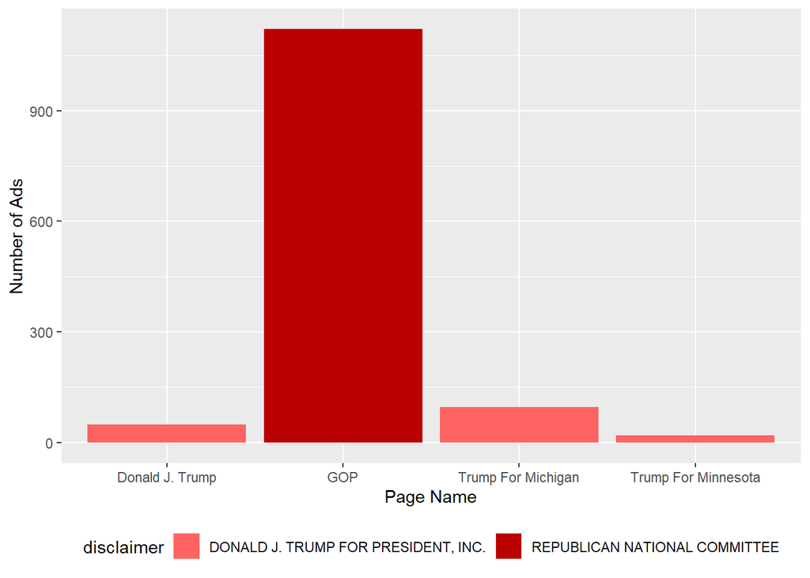

A majority of the ads that were purchased — 1121, about 87% — were funded by the Republican National Committee (RNC), which ran the ads on the official GOP Facebook page. The remaining 162 ads were funded by Donald J. Trump For President, Inc. and were associated with Trump’s official Facebook page and two state-specific pages supporting Trump (Michigan and Minnesota, both swing states in the 2020 presidental election).

# How much was spent on the ads?

Facebook provides spending and impression ranges for each ad in its Ad Library. To perform calculations using this data, a common approach, which I utilize for the visualizations here, is to take the midpoint of the lower and upper spending and impression bounds that Facebook provides.

With this in mind, the below plot visualizes how the total sum of money spent, $448,308.5 USD, was distributed across the Facebook pages that the ads ran on.

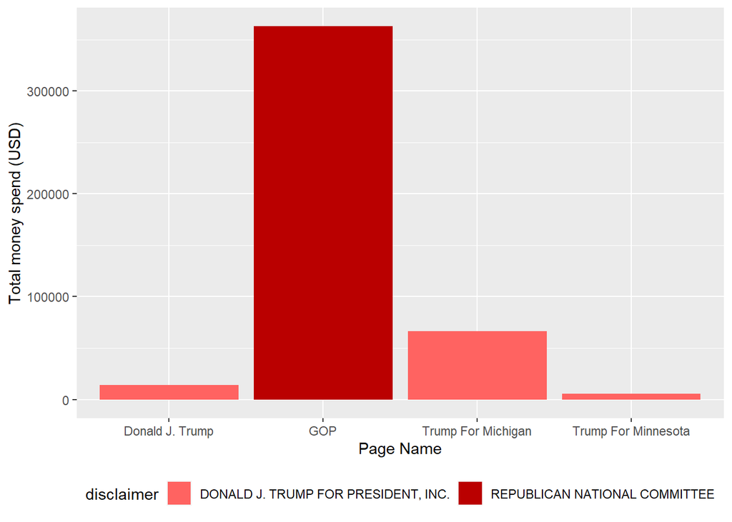

The volume of money spent on each page roughly corresponds with the volume of ads that the advertisers ran on each page.

Notably, however, the amount of spent on ads associated with Trump For Michigan is disproprotionately high compared to the number of ads that ran on the page. This discrepancy can be better understood by looking at how much, on average, an individual ad buy cost for each page:

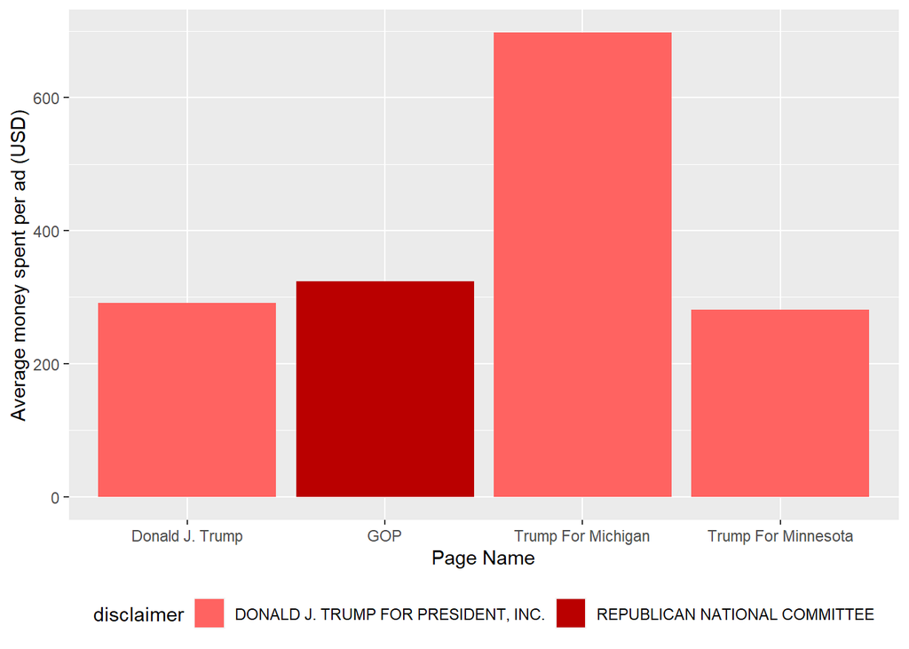

# How widely did the ads circulate?

The below plot visualizes the raw number of impressions that each page’s ads generated in the duration of their run:

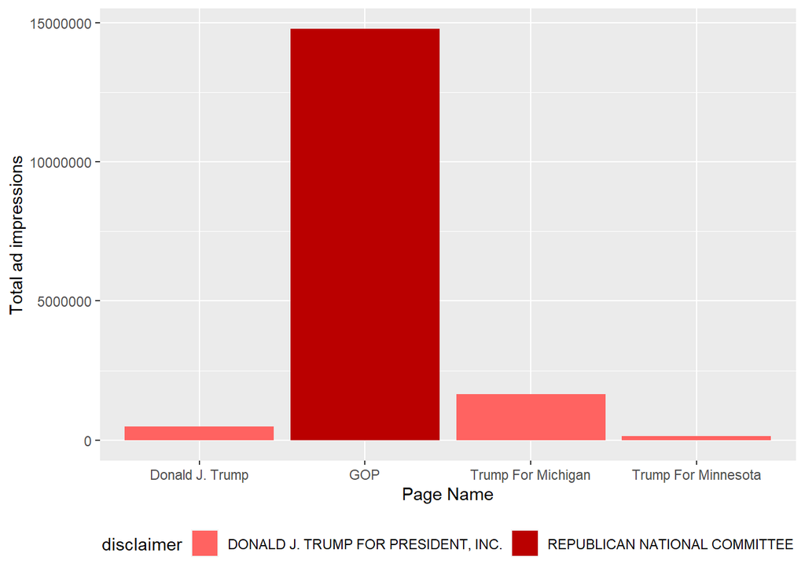

Collectively, the four pages’ advertisements accrued slightly more than 17 million impressions in the time that they ran.

In addition to looking at the raw sum of impressions that the ads accrued, we can compare how many impressions an ad on each page generated on average.

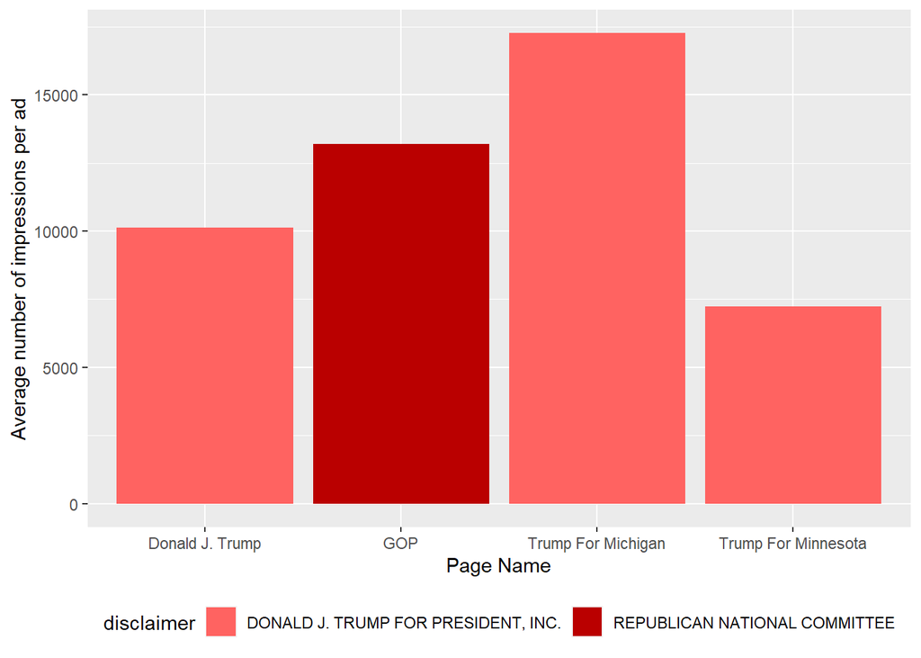

Though only 95 ads ran on Trump For Michigan, a given ad on this page generated more impressions on average (~17,000) than did ads on the three other pages. The GOP, for instance, purchased a much greater volume of ads, but generated fewer impressions on average.

# Which demographics did the ads target?

## Regions

First, we can look at how many impressions were accrued in each state. The below map visualizes impression data for all four pages:

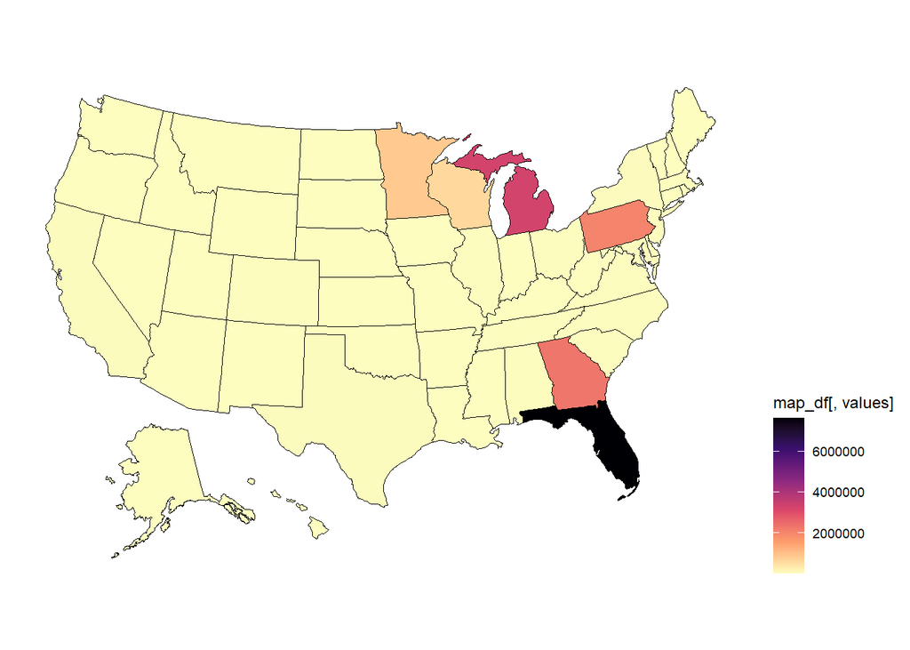

If we compare the distribution of impressions by region between the four pages, we can see differences surface in which state(s) each page targeted.

**GOP**

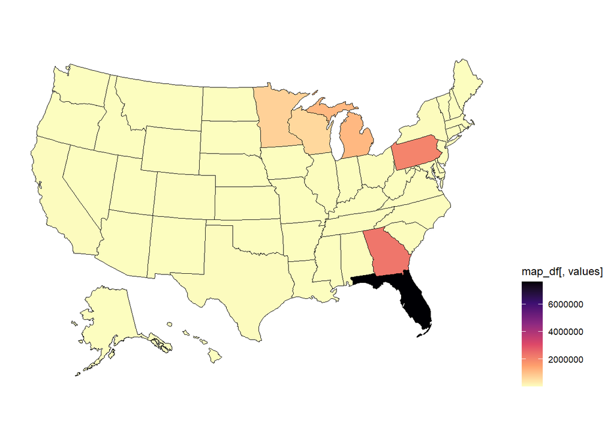

**Donald J. Trump**

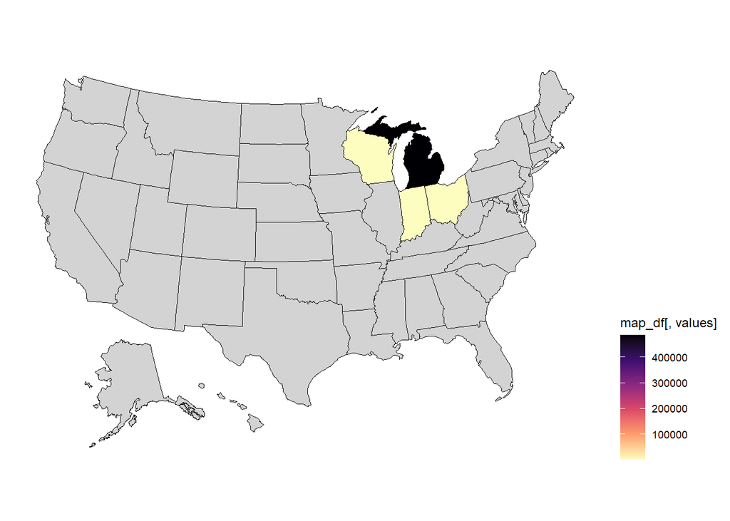

**Trump For Michigan**

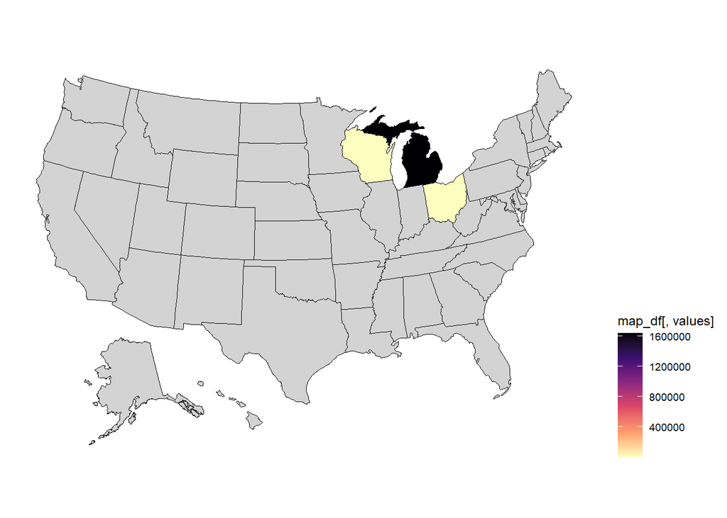

**Trump For Minnesota**

[figure not shown]

## Gender

There is relatively little distinction in the ads’ targeted genders. Overall, slightly more ads were shown to women than men:

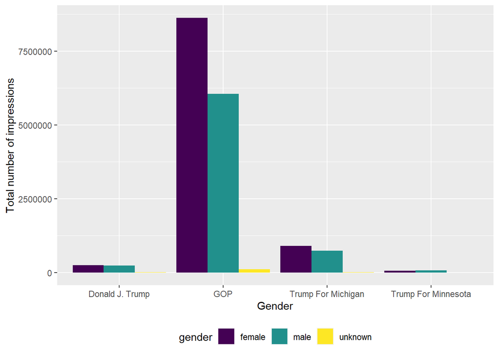

However, this pattern does not true across each individual Facebook page. We can get a clearer sense of the proprotional differences in gender targeting by comparing the average number of impressions an ad generated for women and men across each page.

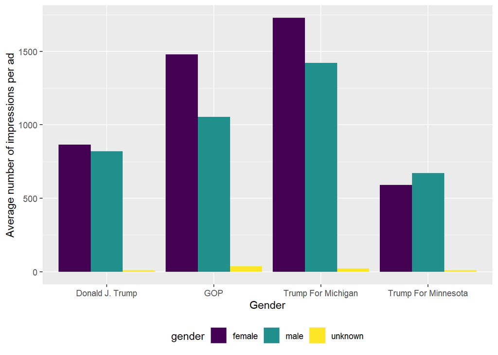

The GOP and Trump For Michigan pages reached several hundred more women than men, while Donald J. Trump’s ads reached *slightly* more women than men. By contrast, Trump For Minnesota ads reached *slightly* more men than women.